# PCA & MDS for Country GDP and Life Expectancy

read data

```r
#read data
dat <- read.csv('gap.csv')

#get gdp data
gdp <- dat[,3:14]
years <- seq(1952, 2007,5)
colnames(gdp) <- years
rownames(gdp) <- dat[,2]

#get lifeExp
lifeExp <- dat[,15:26]
colnames(lifeExp) <- years
rownames(lifeExp) <- dat[,2]
```

explore how GDP and life expectancy have changed

trans data to be structural

```r
#structure the gdp data for plot
gdp_temp <- data.frame()
gdp_temp <- data.frame(gdpPercap=unlist(gdp))
gdp_temp$year <- as.integer(substring(rownames(gdp_temp),1,4))
gdp_temp$continent <- dat[,1]
gdp_temp$country <- dat[,2]
rownames(gdp_temp) <- NULL

gdp_struc <- gdp_temp

#structure the lifeExp data for plot
lifeExp_temp <- data.frame()
lifeExp_temp <- data.frame(lifeExp=unlist(lifeExp))
lifeExp_temp$year <- as.integer(substring(rownames(lifeExp_temp),1,4))
lifeExp_temp$continent <- dat[,1]
lifeExp_temp$country <- dat[,2]
rownames(lifeExp_temp) <- NULL

lifeExp_struc <- lifeExp_temp
```

plot trend of GDP and life expectancy

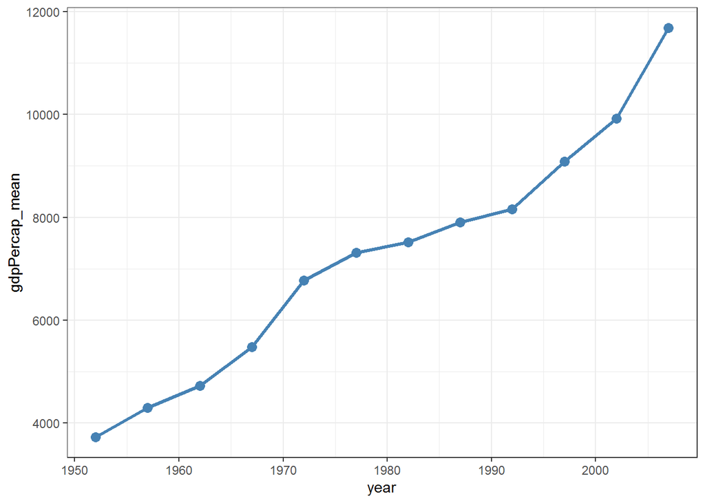

```r
#calculate mean gdp for overall trend
gdp_struc_mean <-
        gdp_struc %>%
        group_by(year) %>%
        summarise(n=n()
                  ,gdpPercap_mean = mean(gdpPercap))
#plot overall gdp trend
g <- ggplot(gdp_struc_mean, aes(year, gdpPercap_mean))
g +
        geom_point(lwd=3,col='steelblue') +
        geom_line(lwd=1.2,col='steelblue') +
        theme_bw()
```

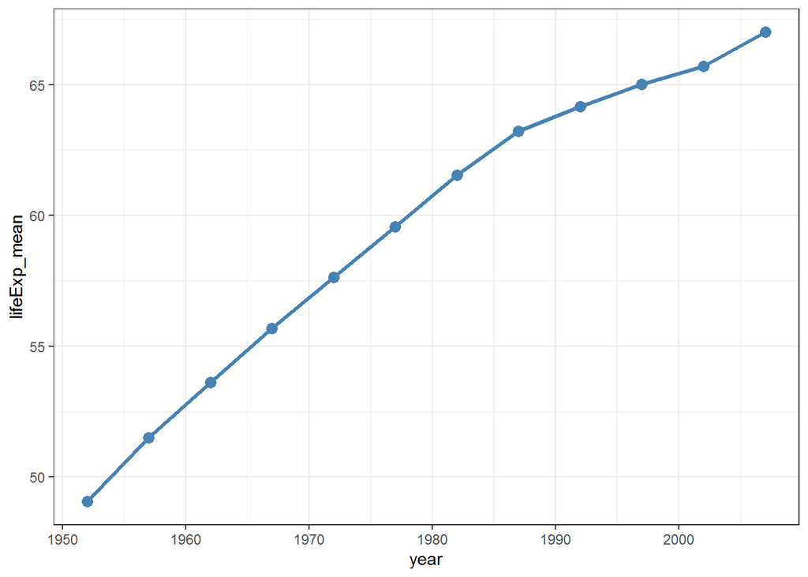

```r
#calculate mean lifeExp for overall trend
lifeExp_struc_mean <-
        lifeExp_struc %>%
        group_by(year) %>%
        summarise(n=n()
                  ,lifeExp_mean = mean(lifeExp))
#plot overall lifeExp trend
g <- ggplot(lifeExp_struc_mean, aes(year, lifeExp_mean))
g +
        geom_point(lwd=3,col='steelblue') +
        geom_line(lwd=1.2,col='steelblue') +
        theme_bw()
```

Overall, both the GDP Per ceptia and the life expectancy growth during 1952 and 2007. From 1972 to 1992, the growth rate is lower.

calculate the average life expectancy and GDP per capita for each continent through time and plot these

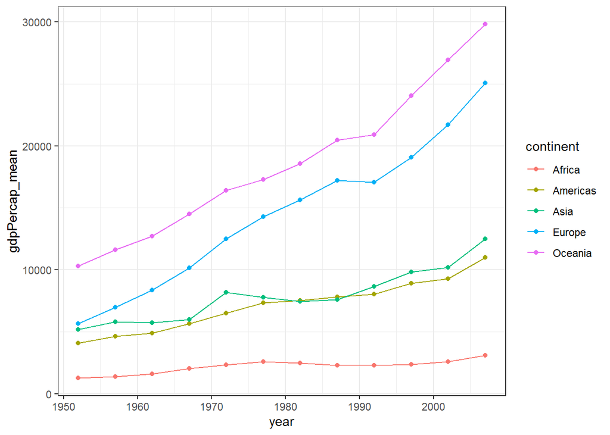

```r
#calculate mean gdp for trend by continent
gdp_struc_mean <-
        gdp_struc %>%
        group_by(continent,year) %>%
        summarise(n=n()
                  ,gdpPercap_mean = mean(gdpPercap))
#plot gdp trend by continent
g <- ggplot(gdp_struc_mean, aes(year, gdpPercap_mean, color = continent))
g +
        geom_point() +
        geom_line() +
        theme_bw()
```

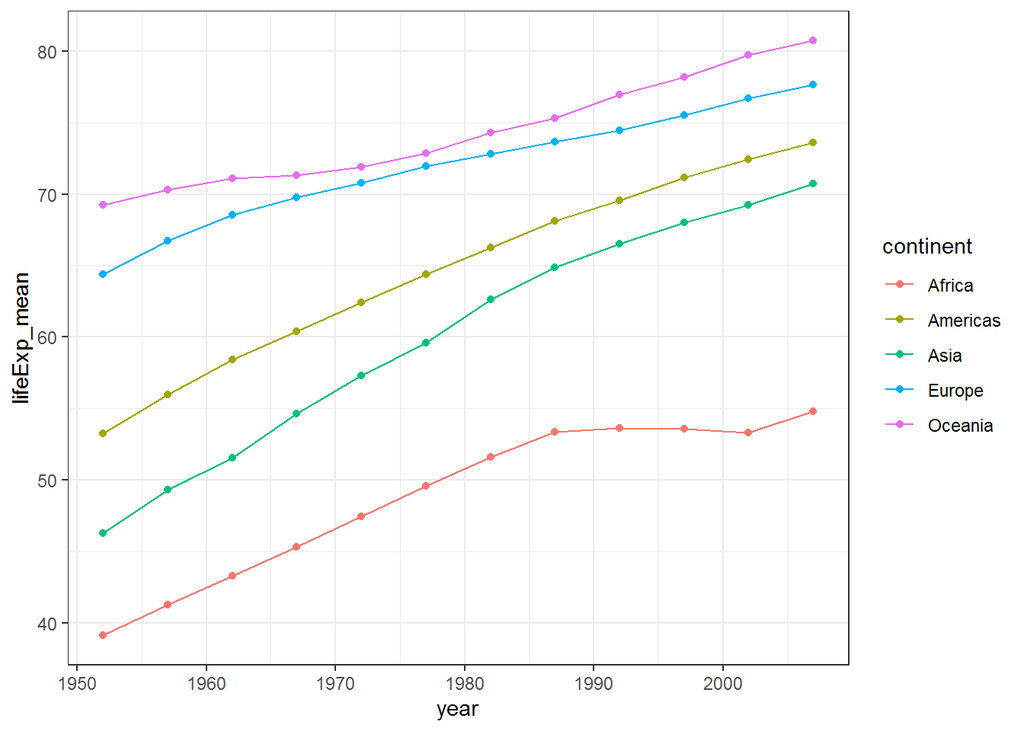

```r
#calculate mean lifeExp for trend by continent
lifeExp_struc_mean <-
        lifeExp_struc %>%
        group_by(continent,year) %>%
        summarise(n=n()
                  ,lifeExp_mean = mean(lifeExp))
#plot lifeExp trend by continent
g <- ggplot(lifeExp_struc_mean, aes(year, lifeExp_mean, color = continent))
g +
        geom_point() +
        geom_line() +
        theme_bw()
```

gdp principal component analysis

```r
#gdp
#work with the log of the GDP
log_gdp <- log(gdp)
#standarization
log_gdp_scale = scale(log_gdp)
#calculate corr
log_gdp_cor <- cor(log_gdp_scale)
#Calculate eigenvalues and eigenvectors
log_gdp_eigen=eigen(log_gdp_cor)
log_gdp_var=log_gdp_eigen$values
options(digits=4, scipen=4)
log_gdp_var
```

```
##  [1] 11.284374  0.533388  0.102700  0.032939  0.018556  0.009267  0.005648
##  [8]  0.003787  0.003544  0.002236  0.001971  0.001592
```

```r
log_gdp_pca_var=log_gdp_var/sum(log_gdp_var)
log_gdp_pca_var
```

```
##  [1] 0.9403645 0.0444490 0.0085583 0.0027449 0.0015463 0.0007722 0.0004706
##  [8] 0.0003156 0.0002953 0.0001863 0.0001642 0.0001326
```

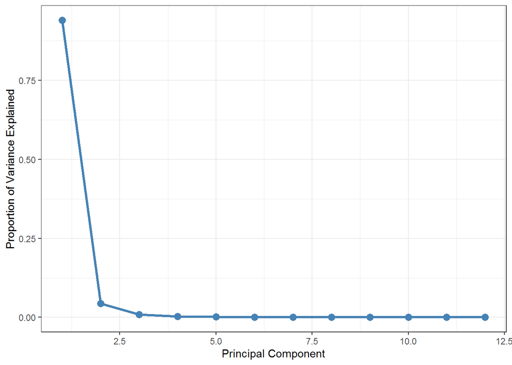

```r
#scree plot
g <- ggplot(,aes(x=1:12,y=log_gdp_pca_var))
g+geom_point(lwd=3,col='steelblue')+
        geom_line(col='steelblue',lwd=1.2)+
        labs(x = "Principal Component", y = "Proportion of Variance Explained")+
        theme_bw()
```

For log_gdp,first components stand for vast majority of the variance. The proportion of variance Explained can be presented in the scree graph. Already two first components stand for almost 98% of variance. Each next component gives not more than 1%. Thus, retaining the first two components is a good choice.